# Day 03 Assignment

Natalie Sawtelle

2025-09-03

## Data for today

A tire manufacturer is interested in investigating the handling properties for different tread patterns. Data were recorded on the stopping distances measured to the nearest foot for a standard sized car to come to a complete stop from a speed of 60 miles per hour. There are six measurements of the stopping distance for each of four different tread patterns labeled A, B, C and D. The same driver and car were used for all 24 measurements and, although not clear from the saved data file, the order of treatments were assigned at random.

**Source:** Ugarte, M. D., Militino, A. F., and Arnholt, A. T. (2008) Probability and Statistics with R. Chapman & Hall/CRC.

## Design Elements

Please identify the design elements in this example.

- What are the **Experimental Units** in this study?
  - *Tires*
- What is the **response variable** in this study?
  - *Stopping distance*
- What is the **factor** in this study?
  - *Tread Type*
- How many **factor levels** are there?
  - *four*
- What are the **treatments**?
  - *A, B, C, D*
- Cite **two ways** that the researcher took to control for nuisance variables and unexplained variability.
  - *The same driver was used*
  - *The same car was used*

## Data Input

Today’s data is distributed via a CSV file on the canvas site.

Download the data and make sure **the CSV file and this Rmd are saved in the same folder** or directory (this is a good time to create a “STA363” folder if you have not already).

```r
tire_tread_study <- read.csv("TireData.csv")
```

## Summary Statistics by Tire Tread

Below, we provide some code that builds a summary table that includes summary statistics for the whole sample as well as summary statistics stratified by tire tread type. On your own, take a few moments to look at the code to decipher how it works.

**NOTE:** You may need to edit the `tire_tread_study` variable if you named the data something else.

```r
bind_rows(tire_tread_study |>
  summarize(N=n(),
            Mean=mean(StopDist),
            SD =  sd(StopDist),
            Min = min(StopDist),
            Median = median(StopDist),
            Max = max(StopDist) ) |>
  mutate(`Tread Type` = "All Tread Types"),
tire_tread_study |>
  group_by(`Tread Type`=TreadType) |>
  summarize(N=n(),
            Mean=mean(StopDist),
            SD =  sd(StopDist),
            Min = min(StopDist),
            Median = median(StopDist),
            Max = max(StopDist) ) ) |>
  select(`Tread Type`, N, Mean, SD, Min, Median, Max) |>
  kable()
```

| Tread Type | N | Mean | SD | Min | Median | Max |
| --- | --- | --- | --- | --- | --- | --- |
| All Tread Types | 24 | 404.2083 | 23.56486 | 353 | 406.0 | 447 |
| A | 6 | 379.6667 | 22.23211 | 353 | 377.5 | 416 |
| B | 6 | 405.1667 | 13.06012 | 394 | 400.0 | 428 |
| C | 6 | 421.6667 | 12.22566 | 403 | 421.5 | 435 |
| D | 6 | 410.3333 | 24.60623 | 378 | 413.0 | 447 |

Based on the table, what conclusions can you make about the stopping times of the different tire tread types.

## Graphical Analysis - Part 1

So far in this class we have generally used Box-Whiskers plots for a graphical exploration of our data. With this data, why do Box-Whiskers plot seem unnecessarily? (hint: look at the sample size).

*Since there are only a total of 6 different results per each treatment, Box-Whisker plots seem to be unnecessary in comparison to dot plots that will be more informative than a summary based of quartiles.*

## Graphical Analysis - Part 2

Build what you consider to be an informative plot so a viewer can compare the stopping distances among the four tire treads.

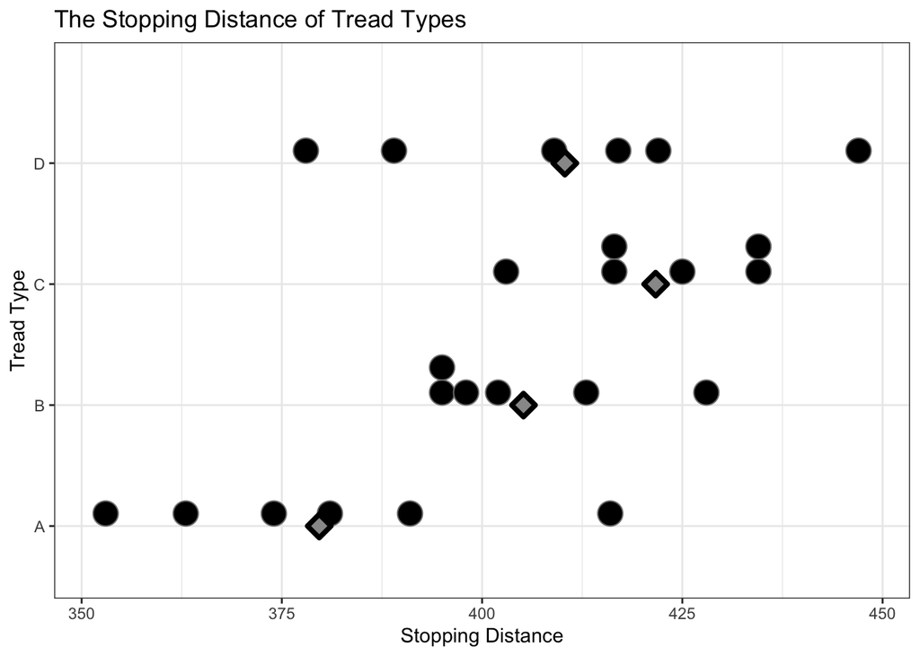

```r
ggplot(tire_tread_study, aes(x=StopDist, y=TreadType)) +
  geom_dotplot(color="gray50") +
  stat_summary(fun=mean, geom="point", shape=23, size=3.5, fill="gray60", stroke=2) +
  labs(x="Stopping Distance",
       y="Tread Type",
       title="The Stopping Distance of Tread Types") +
  scale_x_continuous() +
  theme_bw()
```

## ANOVA Fit

In the below code chunk, fit the ANOVA model for Stopping Distance as a function of Tread Type.

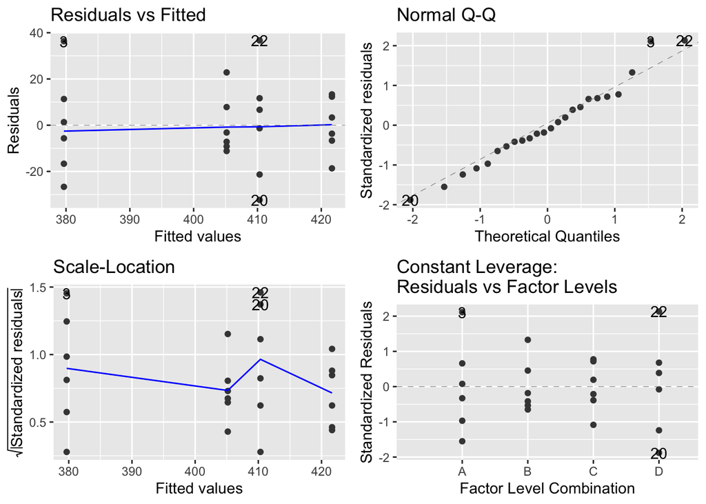

```r
anova_model <-aov(StopDist ~ TreadType, data = tire_tread_study)
autoplot(anova_model)
```

## Residual Analysis

Complete a residual analysis for the fitted ANOVA model in the part above.

```r
summary(anova_model)
```

```
##             Df Sum Sq Mean Sq F value  Pr(>F)
## TreadType    3   5673  1891.0   5.328 0.00732 **
## Residuals   20   7099   354.9
## ---
## Signif. codes:  0 '***' 0.001 '**' 0.01 '*' 0.05 '.' 0.1 ' ' 1
```

- **Independence** – *This experiment used random tread order and the same car and driver, so independence of errors is a reasonable assumption.*
- **Constant variance** – *From the residual analysis vs fit plots, the spread of residuals looks about the same across groups, so constant variance seems correct.*
- **Normality** – *The qqplot of residuals shows some points close to the line, suggesting normality is not incorrect.*

## ANOVA Output

Perform the ANOVA hypothesis test at a 5% significance level. Make sure to interpret the results of the hypothesis test in context.

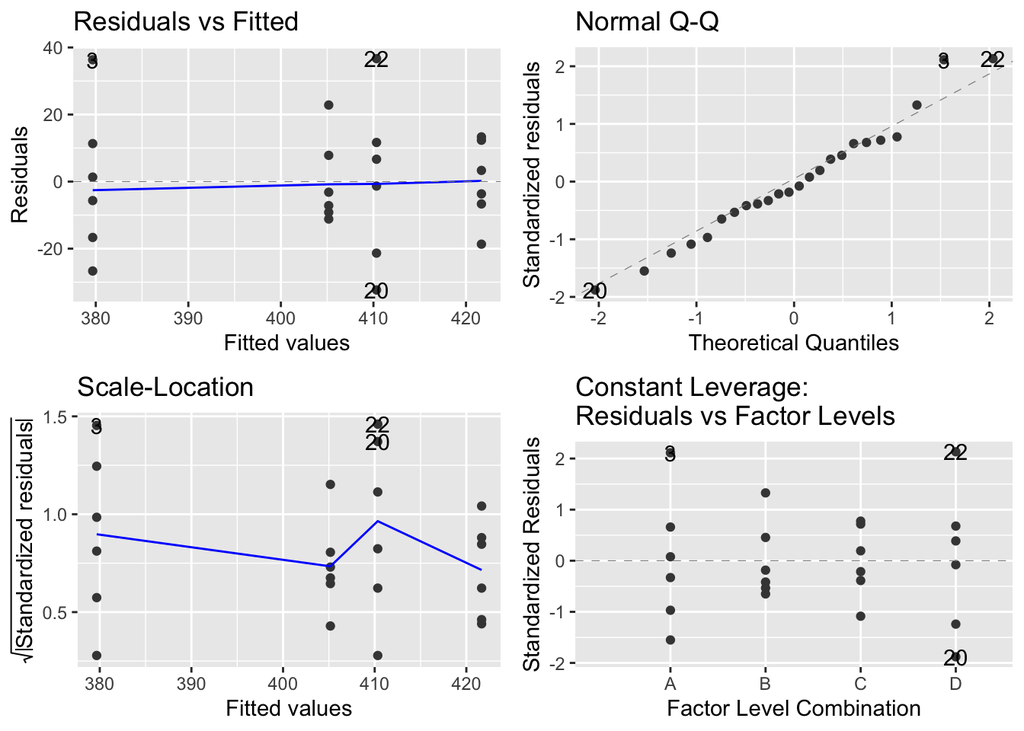

```r
anova_model <-aov(StopDist ~ TreadType, data = tire_tread_study)
autoplot(anova_model)
```

```r
summary(anova_model)
```

```
##             Df Sum Sq Mean Sq F value  Pr(>F)
## TreadType    3   5673  1891.0   5.328 0.00732 **
## Residuals   20   7099   354.9
## ---
## Signif. codes:  0 '***' 0.001 '**' 0.01 '*' 0.05 '.' 0.1 ' ' 1
```

*At the 5% significance level, the p-value from the ANOVA is 0.0073. Since this p-value is less than 0.05, we reject the null hypothesis and conclude that at least one tire tread type has a different mean stopping distance.*

## Multiple Comparisons

You should have seen a significant result in the previous work. Perform a Tukey pairwise multiple comparison to determine the difference in mean stopping distance for the four tread types.

```r
library(emmeans)
tread_mc <- emmeans(anova_model, ~TreadType)
contrast(tread_mc, "tukey")
```

```
##  contrast estimate   SE df t.ratio p.value
##  A - B      -25.50 10.9 20  -2.344  0.1213
##  A - C      -42.00 10.9 20  -3.861  0.0050
##  A - D      -30.67 10.9 20  -2.819  0.0480
##  B - C      -16.50 10.9 20  -1.517  0.4465
##  B - D       -5.17 10.9 20  -0.475  0.9637
##  C - D       11.33 10.9 20   1.042  0.7274
##
## P value adjustment: tukey method for comparing a family of 4 estimates
```

## Contextual Findings

Make some overall contextual findings on this experiment.